# R Notebook

# Final Project

## Predict the chance of admission of a student in a particular university

```r
library(ggcorrplot)
library(lattice)
library(glmnet)
library(mltools)
library(data.table)
library(keras)
library(tfruns)
library(tidyr)
library(GGally)
library(purrr)
library(knitr)
library(scales)
library(psych)
library(dplyr)
library(caret)
library(ggplot2)
```

```r
data <- read.csv("Admission_Predict.csv")
data
```

| Serial.No. | GRE.Score | TOEFL.Score | University.Rating | SOP | LOR | CGPA | Research | Chance.of.Admit |
| --- | --- | --- | --- | --- | --- | --- | --- | --- |
| 1 | 337 | 118 | 4 | 4.5 | 4.5 | 9.65 | 1 | 0.92 |
| 2 | 324 | 107 | 4 | 4.0 | 4.5 | 8.87 | 1 | 0.76 |
| 3 | 316 | 104 | 3 | 3.0 | 3.5 | 8.00 | 1 | 0.72 |
| 4 | 322 | 110 | 3 | 3.5 | 2.5 | 8.67 | 1 | 0.80 |
| 5 | 314 | 103 | 2 | 2.0 | 3.0 | 8.21 | 0 | 0.65 |
| 6 | 330 | 115 | 5 | 4.5 | 3.0 | 9.34 | 1 | 0.90 |
| 7 | 321 | 109 | 3 | 3.0 | 4.0 | 8.20 | 1 | 0.75 |
| 8 | 308 | 101 | 2 | 3.0 | 4.0 | 7.90 | 0 | 0.68 |
| 9 | 302 | 102 | 1 | 2.0 | 1.5 | 8.00 | 0 | 0.50 |
| 10 | 323 | 108 | 3 | 3.5 | 3.0 | 8.60 | 0 | 0.45 |

[output cut: 390 more lines]

### Exploratory Data Analysis

```r
str(data)
```

```
'data.frame':   400 obs. of  9 variables:
 $ Serial.No.       : int  1 2 3 4 5 6 7 8 9 10 ...
 $ GRE.Score        : int  337 324 316 322 314 330 321 308 302 323 ...
 $ TOEFL.Score      : int  118 107 104 110 103 115 109 101 102 108 ...
 $ University.Rating: int  4 4 3 3 2 5 3 2 1 3 ...
 $ SOP              : num  4.5 4 3 3.5 2 4.5 3 3 2 3.5 ...
 $ LOR              : num  4.5 4.5 3.5 2.5 3 3 4 4 1.5 3 ...
 $ CGPA             : num  9.65 8.87 8 8.67 8.21 9.34 8.2 7.9 8 8.6 ...
 $ Research         : int  1 1 1 1 0 1 1 0 0 0 ...
 $ Chance.of.Admit  : num  0.92 0.76 0.72 0.8 0.65 0.9 0.75 0.68 0.5 0.45 ...
```

```r
summary(data)
```

```
   Serial.No.      GRE.Score      TOEFL.Score    University.Rating      SOP           LOR             CGPA          Research      Chance.of.Admit
 Min.   :  1.0   Min.   :290.0   Min.   : 92.0   Min.   :1.000     Min.   :1.0   Min.   :1.000   Min.   :6.800   Min.   :0.0000   Min.   :0.3400
 1st Qu.:100.8   1st Qu.:308.0   1st Qu.:103.0   1st Qu.:2.000     1st Qu.:2.5   1st Qu.:3.000   1st Qu.:8.170   1st Qu.:0.0000   1st Qu.:0.6400
 Median :200.5   Median :317.0   Median :107.0   Median :3.000     Median :3.5   Median :3.500   Median :8.610   Median :1.0000   Median :0.7300
 Mean   :200.5   Mean   :316.8   Mean   :107.4   Mean   :3.087     Mean   :3.4   Mean   :3.453   Mean   :8.599   Mean   :0.5475   Mean   :0.7244
 3rd Qu.:300.2   3rd Qu.:325.0   3rd Qu.:112.0   3rd Qu.:4.000     3rd Qu.:4.0   3rd Qu.:4.000   3rd Qu.:9.062   3rd Qu.:1.0000   3rd Qu.:0.8300
 Max.   :400.0   Max.   :340.0   Max.   :120.0   Max.   :5.000     Max.   :5.0   Max.   :5.000   Max.   :9.920   Max.   :1.0000   Max.   :0.9700
```

There are total 9 variables among which we do not need the serial number variable.

The variable names and their explanations are as follows:

1. **Serial.No.:** A unique identifier for each student in the dataset.
2. **GRE.Score:** The student’s score on the Graduate Record Examination (GRE) standardized test.
3. **TOEFL.Score:** The student’s score on the Test of English as a Foreign Language (TOEFL) standardized test.
4. **University.Rating:** The rating of the university where the student is applying, on a scale of 1 to 5.
5. **SOP:** The student’s Statement of Purpose (SOP) score, as rated by the university admissions committee.
6. **LOR:** The student’s Letter of Recommendation (LOR) score, as rated by the university admissions committee.
7. **CGPA:** The student’s Cumulative Grade Point Average (CGPA) from their undergraduate studies.
8. **Research:** A binary variable indicating whether or not the student has research experience.
9. **Chance.of.Admit:** The probability of the student being admitted to the university, as determined by the university admissions committee.

We are going to remove the serial number from the data as it is not necessary.

The Chance.of.Admit is our target variable.

```r
data = data[, -c(1)]
data
```

| GRE.Score | TOEFL.Score | University.Rating | SOP | LOR | CGPA | Research | Chance.of.Admit |
| --- | --- | --- | --- | --- | --- | --- | --- |
| 337 | 118 | 4 | 4.5 | 4.5 | 9.65 | 1 | 0.92 |
| 324 | 107 | 4 | 4.0 | 4.5 | 8.87 | 1 | 0.76 |
| 316 | 104 | 3 | 3.0 | 3.5 | 8.00 | 1 | 0.72 |
| 322 | 110 | 3 | 3.5 | 2.5 | 8.67 | 1 | 0.80 |
| 314 | 103 | 2 | 2.0 | 3.0 | 8.21 | 0 | 0.65 |
| 330 | 115 | 5 | 4.5 | 3.0 | 9.34 | 1 | 0.90 |
| 321 | 109 | 3 | 3.0 | 4.0 | 8.20 | 1 | 0.75 |
| 308 | 101 | 2 | 3.0 | 4.0 | 7.90 | 0 | 0.68 |
| 302 | 102 | 1 | 2.0 | 1.5 | 8.00 | 0 | 0.50 |
| 323 | 108 | 3 | 3.5 | 3.0 | 8.60 | 0 | 0.45 |

[output cut: 390 more lines]

Lets see if there is any missing values in any column of dataset.

```r
colSums(is.na(data))
```

```
        GRE.Score       TOEFL.Score University.Rating               SOP               LOR              CGPA          Research   Chance.of.Admit
                0                 0                 0                 0                 0                 0                 0                 0
```

We do not have any missing value in our data.

Now we are going to show the distribution of our target variable.

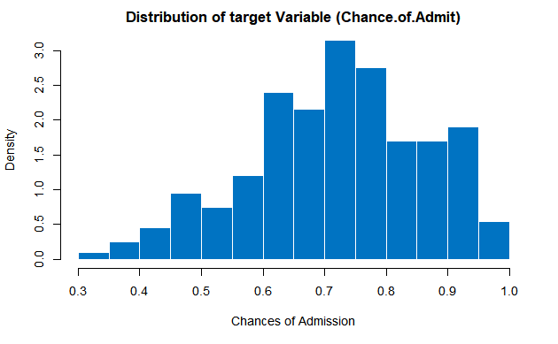

```r
Chances_of_Admission <- data$Chance.of.Admit
options(scipen=999)
# Distribution of Chance.of.Admit
hist(data$Chance.of.Admit, col="#0073c2ff",
     border = "white",
     probability = TRUE,
     xlab = "Chances of Admission",
     main="Distribution of target Variable (Chance.of.Admit)"
     )
```

In this dataset, the categorical variables are:

- Serial.No.: This variable represents a unique identifier for each student in the dataset. Although this variable is represented by integers, it is a categorical variable since it is just a label and doesn’t have any numerical meaning or order.
- University.Rating: This variable represents the rating of the university where the student is applying, on a scale of 1 to 5. Even though the variable is represented by integers, it is a categorical variable because it has a fixed set of values that do not have any numerical order.
- Research: This variable is a binary variable indicating whether or not the student has research experience. It only has two possible values, 0 or 1, and therefore is a categorical variable.

The numerical variables in the dataset are:

- GRE.Score: The student’s score on the Graduate Record Examination (GRE) standardized test.
- TOEFL.Score: The student’s score on the Test of English as a Foreign Language (TOEFL) standardized test.
- SOP: The student’s Statement of Purpose (SOP) score, as rated by the university admissions committee.
- LOR: The student’s Letter of Recommendation (LOR) score, as rated by the university admissions committee.
- CGPA: The student’s Cumulative Grade Point Average (CGPA) from their undergraduate studies.
- Chance.of.Admit: The probability of the student being admitted to the university, as determined by the university admissions committee.

First we are going to find the association between the target variable and all other numeric variables.

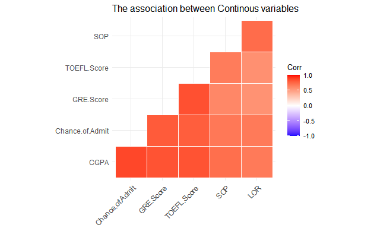

```r
# Extract all numerical variables from the original dataframe

numerical_data <- c("GRE.Score", "TOEFL.Score", "SOP", "LOR", "CGPA", "Chance.of.Admit")

#make a dataframe of those numerical variable
data_num <- data[,numerical_data]

# find correlation of all numerical variables
corr<-cor(data_num)
my_corr<-ggcorrplot(corr,hc.order = TRUE, type = "lower",  title = "The association between Continous variables", outline.col = "white")
my_corr + theme(axis.text.x = element_text(size = 10), axis.text.y =
element_text(size = 10))
```

```r
corr
```

```
                GRE.Score TOEFL.Score       SOP       LOR      CGPA Chance.of.Admit
GRE.Score       1.0000000   0.8359768 0.6128307 0.5575545 0.8330605       0.8026105
TOEFL.Score     0.8359768   1.0000000 0.6579805 0.5677209 0.8284174       0.7915940
SOP             0.6128307   0.6579805 1.0000000 0.7295925 0.7181440       0.6757319
LOR             0.5575545   0.5677209 0.7295925 1.0000000 0.6702113       0.6698888
CGPA            0.8330605   0.8284174 0.7181440 0.6702113 1.0000000       0.8732891
Chance.of.Admit 0.8026105   0.7915940 0.6757319 0.6698888 0.8732891       1.0000000
```

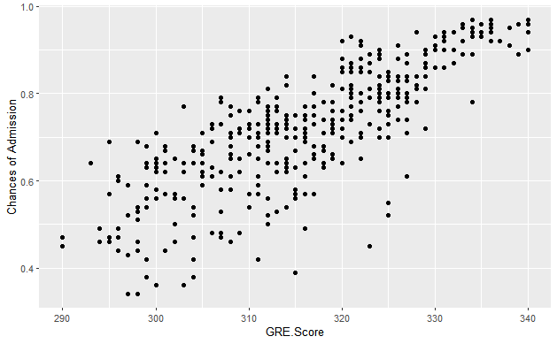

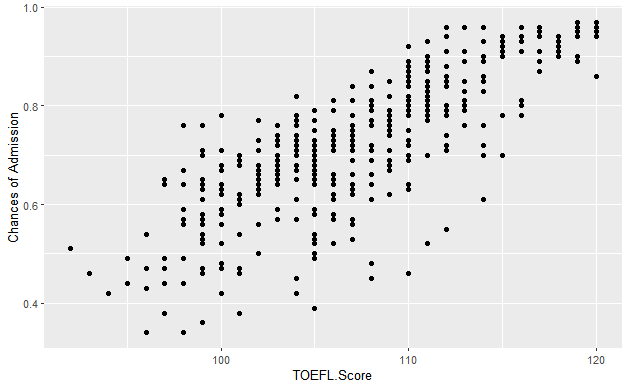

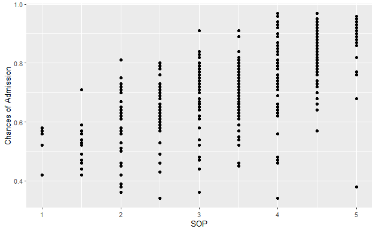

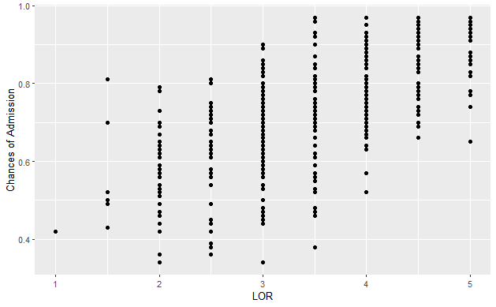

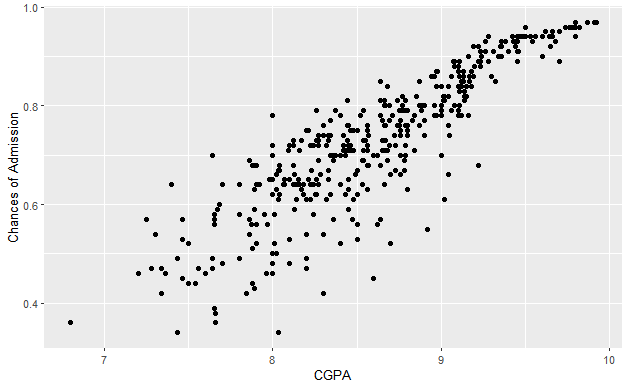

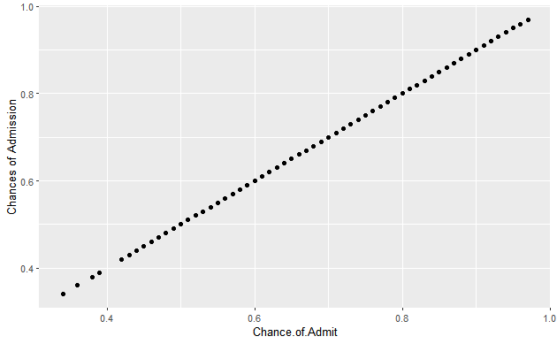

```r
# Create scatter plots for each numeric variable with Chance.of.Admit
plots <- lapply(numerical_data, function(x) {
  ggplot(data, aes(x = !!sym(x), y = Chance.of.Admit)) +
    geom_point() +
    labs(x = x, y = "Chances of Admission")
})

# Print all plots
for (plot in plots) {
  print(plot)
}
```

```r
df1 = data[, c(numerical_data)]
model <- aov(Chance.of.Admit ~ ., data=df1)
summary(model)
```

```
             Df Sum Sq Mean Sq F value               Pr(>F)
GRE.Score     1  5.227   5.227 1255.87 < 0.0000000000000002 ***
TOEFL.Score   1  0.392   0.392   94.20 < 0.0000000000000002 ***
SOP           1  0.231   0.231   55.44    0.000000000000612 ***
LOR           1  0.200   0.200   47.95    0.000000000017884 ***
CGPA          1  0.425   0.425  102.09 < 0.0000000000000002 ***
Residuals   394  1.640   0.004
---
Signif. codes:  0 ‘***’ 0.001 ‘**’ 0.01 ‘*’ 0.05 ‘.’ 0.1 ‘ ’ 1
```

While looking at p-values, we can say that there is a significant association between target variable and all other continuous variables.

```r
# identify categorical variables
cat_vars <- c("University.Rating", "Research")

cat_df <- data[, c("Chance.of.Admit", cat_vars)]
cat_df$University.Rating <- factor(cat_df$University.Rating)
cat_df$Research <- factor(cat_df$Research)
str(cat_df)
```

```
'data.frame':   400 obs. of  3 variables:
 $ Chance.of.Admit  : num  0.92 0.76 0.72 0.8 0.65 0.9 0.75 0.68 0.5 0.45 ...
 $ University.Rating: Factor w/ 5 levels "1","2","3","4",..: 4 4 3 3 2 5 3 2 1 3 ...
 $ Research         : Factor w/ 2 levels "0","1": 2 2 2 2 1 2 2 1 1 1 ...
```

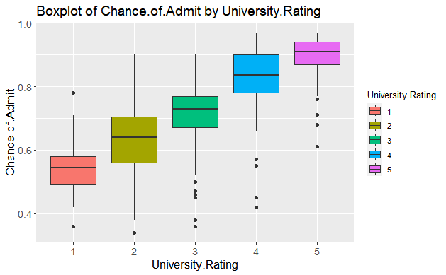

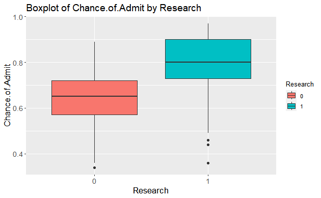

```r
# Create boxplots for each categorical variable
for (var in cat_vars) {
  p <- ggplot(cat_df, aes(x = .data[[var]], y = Chance.of.Admit, fill = .data[[var]])) +
    geom_boxplot() +
    labs(title = paste("Boxplot of Chance.of.Admit by", var), x = var, y = "Chance.of.Admit") +
    theme(plot.title = element_text(size = 16), axis.title = element_text(size = 14), axis.text = element_text(size = 12)) +
    scale_fill_hue(name = var)
  print(p)
}
```

```r
for (var in cat_vars) {

  t <- table(cat_df[[var]], cat_df$Chance.of.Admit)

  chisq <- chisq.test(t)
  cat(paste0("Chi-squared test for association between Chance.of.Admit and ", var, ":\n"))
  print(chisq)
  cat("\n")
}
```

```
Chi-squared test for association between Chance.of.Admit and University.Rating:

    Pearson's Chi-squared test

data:  t
X-squared = 581.44, df = 236, p-value < 0.00000000000000022
```

```
Chi-squared test for association between Chance.of.Admit and Research:

    Pearson's Chi-squared test

data:  t
X-squared = 175.37, df = 59, p-value = 0.0000000000001762
```

After all the tests and plots, we can conclude that all our variables are strongly associated with the target variables.

Finally we are going to split our dataset into training and testing data using caret createDataPartition method.

```r
inTrain <- createDataPartition(data$Chance.of.Admit, p = 0.8, list = F)
train_data <-  data[inTrain, ]
test_data <- data[-inTrain, ]
```

```r
dim(train_data)
```

```
[1] 322   8
```

```r
dim(test_data)
```

```
[1] 78  8
```

### Creating Predictive model:

### Creating Regularized Linear Regression Models

#### 1- Lasso Regression:

```r
set.seed(1234)
tr_ctr = trainControl( method = "repeatedcv",
                       number = 10,
                       repeats = 5,
                       verboseIter = T
                       )
lasso <- train(
  Chance.of.Admit ~ .,
  data = train_data,
  preProcess = c("knnImpute", "nzv"),
  method = "glmnet",
  tuneGrid = expand.grid(alpha= 1,
                         lambda = seq(0.01, 0.2, length = 5)),
  trControl =  tr_ctr
)
```

```r
# print the tuned parameter
lasso$bestTune
```

|  | alpha | lambda |
| --- | --- | --- |
| 1 | 1 | 0.01 |

```r
# get the coefficients for the best tuned model
lasso_coefficient <- coef(lasso$finalModel, s = lasso$bestTune$lambda)
lasso_coefficient
```

```
8 x 1 sparse Matrix of class "dgCMatrix"
                           s1
(Intercept)       0.723695652
GRE.Score         0.017431230
TOEFL.Score       0.018371228
University.Rating 0.002733825
SOP               .
LOR               0.015835942
CGPA              0.066460940
Research          0.008780275
```

```r
# check if Lasso shrink some of the coefficients to zero
sum(lasso_coefficient[-1] == 0) > 0
```

```
[1] TRUE
```

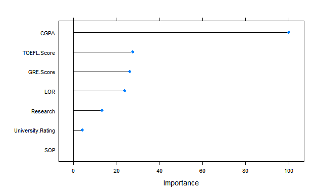

```r
plot(varImp(lasso, scale = T  ))
```

```r
predictions<- predict(lasso,
             newdata = test_data,
             )

lasso_rmse <- RMSE(predictions, test_data$Chance.of.Admit)
cat(paste("The RMSE Value of Lasso Regression is: ", lasso_rmse))
```

```
The RMSE Value of Lasso Regression is:  0.0641004414217388
```

#### 2- Ridge Regression:

```r
set.seed(1)
tr_ctr = trainControl( method = "repeatedcv",
                       number = 10,
                       repeats = 5,
                       verboseIter = T
                       )
ridge <- train(
  Chance.of.Admit ~ .,
  data = train_data,

  preProcess = c("knnImpute", "nzv"),
  method = "glmnet",
  tuneGrid = expand.grid(alpha= 0,
                         lambda = seq(0.0001, 1, length = 5)),
  trControl =  tr_ctr
)
```

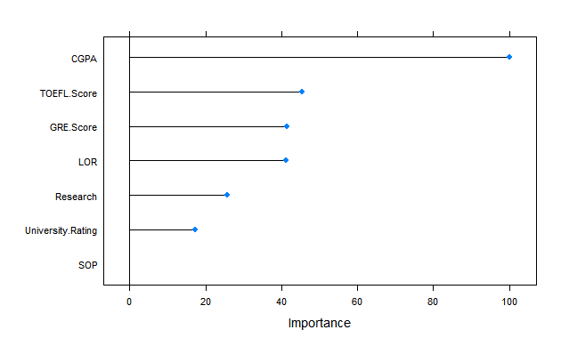

```r
plot(varImp(ridge, scale = T  ))
```

```r
predictions<- predict(ridge,
             newdata = test_data,

             )

ridge_rmse <- RMSE(predictions, test_data$Chance.of.Admit)
cat(paste("The RMSE Value of Ridge Regression is: ", ridge_rmse))
```

```
The RMSE Value of Ridge Regression is:  0.0641290466872944
```

#### 3- Elastic Net Regression:

```r
set.seed(1)
tr_ctr = trainControl( method = "repeatedcv",
                       number = 10,
                       repeats = 5,
                       verboseIter = T
                       )
elastic_net <- train(
  Chance.of.Admit ~ .,
  data = train_data,

  preProcess = c("knnImpute", "nzv"),
  method = "glmnet",
  tuneGrid = expand.grid(alpha= seq(0,1,length = 10),
                         lambda = seq(0.0001, 0.2, length = 5)),
  trControl =  tr_ctr
)
```

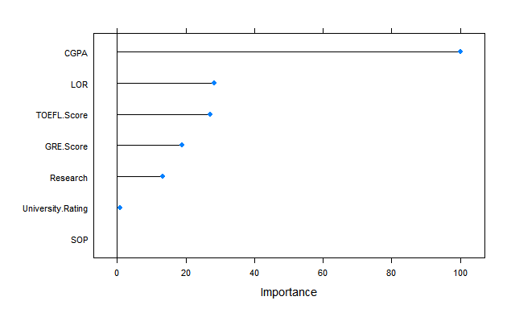

```r
plot(varImp(elastic_net, scale = T))
```

```r
predictions<- predict(elastic_net,
             newdata = test_data,

             )

en_rmse <- RMSE(predictions, test_data$Chance.of.Admit)
cat(paste("The RMSE Value of Elastic Net Regression is: ", en_rmse))
```

```
The RMSE Value of Elastic Net Regression is:  0.0629988893784097
```

### Creating Tree-Ensemble and SVM Models

#### 4- Random Forest Model:

```r
set.seed(1)
tr_ctr = trainControl( method = "repeatedcv",
                       number = 10,
                       repeats = 5,
                       verboseIter = T
                       )
rndmForest <- train(
  Chance.of.Admit ~ .,
  data = train_data,
  preProcess = c("knnImpute", "nzv"),
  method = "rf",
  importance = T,
  trControl =  tr_ctr

)
```

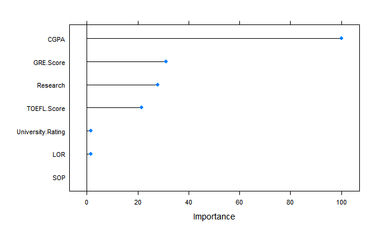

```r
plot(varImp(rndmForest, scale = T))
```

```r
p_rf<- predict(rndmForest,
             newdata = test_data,
             )

rf_rmse <- RMSE(p_rf, test_data$Chance.of.Admit)
cat(paste("The RMSE Value of Random Forest Model is: ", rf_rmse))
```

```
The RMSE Value of Random Forest Model is:  0.0674256875497384
```

#### 5- Gradient Boosted Model:

```r
set.seed(1)
tr_ctr = trainControl( method = "repeatedcv",
                       number = 10,
                       repeats = 5,
                       verboseIter = T
                       )
gbm <- train(
  Chance.of.Admit ~ .,
  data = train_data,
  method = "gbm",
  trControl =  tr_ctr

)
```

```r
p_gbm<- predict(gbm,
             newdata = test_data,
             )

gbm_rmse <- RMSE(p_gbm, test_data$Chance.of.Admit)
cat(paste("The RMSE Value of Gradient Boosted is: ", gbm_rmse))
```

```
The RMSE Value of Gradient Boosted is:  0.0638243633894913
```

#### 6- Linear SVM Model:

```r
set.seed(1)
tr_ctr = trainControl( method = "repeatedcv",
                       number = 10,
                       repeats = 5,
                       verboseIter = T
                       )
svm <- train(
  Chance.of.Admit ~ .,
  data = train_data,
  preProcess = c("knnImpute", "nzv"),
  method = "svmLinear",
  importance = T,
  trControl =  tr_ctr

)
```

```r
p_svm <- predict(svm,
             newdata = test_data,
             )

svm_rmse <- RMSE(p_svm, test_data$Chance.of.Admit)
cat(paste("The RMSE Value of Linear SVM Regression is: ", svm_rmse))
```

```
The RMSE Value of Linear SVM Regression is:  0.0654890974636356
```

#### 7- Radial SVM:

```r
set.seed(1)
tr_ctr = trainControl( method = "repeatedcv",
                       number = 10,
                       repeats = 5,
                       verboseIter = T
                       )
svmRad <- train(
  Chance.of.Admit ~ .,
  data = train_data,
  preProcess = c("knnImpute", "nzv"),
  method = "svmRadial",
  importance = T,
  trControl =  tr_ctr

)
```

```r
p_svmRad <- predict(svmRad,
             newdata = test_data,
             )

svmRad_rmse <- RMSE(p_svmRad, test_data$Chance.of.Admit)
cat(paste("The RMSE Value of Radial SVM is: ", svmRad_rmse))
```

```
The RMSE Value of Radial SVM is:  0.0694440557272084
```

Compare the RMSE of all the seven models we used above using resamples function

```r
model_list <- list(Lasso_Regression= lasso, Ridge_Regression = ridge, ElasticNet_Regression = elastic_net, RandomForest_Model = rndmForest, GradientBoost_Model = gbm, SVMLinear_Model = svm, SVMRadial_Model = svmRad)
res <- resamples(model_list)
summary(res)
```

```
Call:
summary.resamples(object = res)

Models: Lasso_Regression, Ridge_Regression, ElasticNet_Regression, RandomForest_Model, GradientBoost_Model, SVMLinear_Model, SVMRadial_Model
Number of resamples: 50

MAE
                            Min.    1st Qu.     Median       Mean    3rd Qu.       Max. NA's
Lasso_Regression      0.03420532 0.04273424 0.04688574 0.04718190 0.05124695 0.06128790    0
Ridge_Regression      0.02524768 0.04197973 0.04613472 0.04583136 0.05056731 0.06010766    0
ElasticNet_Regression 0.02511513 0.04137471 0.04600524 0.04591316 0.05018028 0.06202339    0
RandomForest_Model    0.03048539 0.04352385 0.04779672 0.04708669 0.05117975 0.06342754    0
GradientBoost_Model   0.03245085 0.04354913 0.04791087 0.04821116 0.05302297 0.06673413    0
SVMLinear_Model       0.02553461 0.04061698 0.04576752 0.04497541 0.04950317 0.06110272    0
SVMRadial_Model       0.03144554 0.04370359 0.04815331 0.04854405 0.05380967 0.06628996    0

RMSE
                            Min.    1st Qu.     Median       Mean    3rd Qu.       Max. NA's
Lasso_Regression      0.04503126 0.05625090 0.06509572 0.06532059 0.07283120 0.09001807    0
Ridge_Regression      0.03128054 0.05759609 0.06449483 0.06416382 0.07412072 0.09043905    0
ElasticNet_Regression 0.03082458 0.05800579 0.06371002 0.06404450 0.07268024 0.09133359    0
RandomForest_Model    0.04089140 0.06085044 0.06681363 0.06615600 0.07378299 0.09478309    0
GradientBoost_Model   0.03984690 0.06115743 0.06812217 0.06806237 0.07490867 0.09545990    0
SVMLinear_Model       0.03280718 0.05832596 0.06457102 0.06462637 0.07523143 0.09191794    0
SVMRadial_Model       0.04238463 0.06111318 0.07066309 0.06888675 0.07475012 0.09509457    0

Rsquared
                           Min.   1st Qu.    Median      Mean   3rd Qu.      Max. NA's
Lasso_Regression      0.6261489 0.7598201 0.8057361 0.7966225 0.8533043 0.9025537    0
Ridge_Regression      0.6207209 0.7444930 0.8114480 0.7964404 0.8522082 0.9525379    0
ElasticNet_Regression 0.6144184 0.7483970 0.8024535 0.7959636 0.8530220 0.9527885    0
RandomForest_Model    0.5853274 0.7330116 0.8134134 0.7877800 0.8381607 0.9175170    0
GradientBoost_Model   0.5603093 0.7072340 0.8013806 0.7734244 0.8415037 0.9264110    0
SVMLinear_Model       0.6146856 0.7491986 0.8107123 0.7972126 0.8507641 0.9484118    0
SVMRadial_Model       0.5872182 0.7336278 0.7796964 0.7748005 0.8279358 0.8812254    0
```

For MAE and RMSE, the performance of all models is quite similar, with mean values ranging from 0.0449 to 0.0485 for MAE and 0.064 to 0.069 for RMSE. The median values are also similar for all models, indicating that the models are consistently performing well.

For Rsquared, all models have a mean value ranging from 0.773 to 0.80, indicating that the models are explaining 78-80% of the variation in the dataset. The interquartile range (IQR) is quite narrow, indicating that the performance is consistent across all repetitions.

Overall, the models appear to be performing well on the given dataset, with no significant difference in their performance.

### Creating Neural Network model:

```r
#Split the Training data again to 90% train and 10% validation
inTrain <- createDataPartition(train_data$Chance.of.Admit, p = 0.90, list = F)
train_df <- train_data[inTrain, ]
val_df <- train_data[-inTrain, ]
test_df <- test_data
```

we are not Imputing the missing values using knnImpute method, since we don’t have any missing values.

Our categorical variables are already encoded and we do not need to encode them any more.

We will have to manually remove variables with little or no variance.

```r
nzv_train <- nearZeroVar(train_df)
nzv_train
```

```
integer(0)
```

Prepare the feature and target variables from train_df, test_df and val_df

[output not shown]

[output cut: 282 more lines]

Now we will create a neural network with atleast two hidden layers to predict the chances of Admission

```r
model <- keras_model_sequential() %>%
  layer_dense(units = 128, activation = "relu",
              input_shape = dim(train_X)[2]) %>%
  layer_dense(units = 64, activation = "relu") %>%
  layer_dropout(0.3) %>%
  layer_dense(units = 32, activation = "relu") %>%
  layer_dropout(0.4) %>%
  layer_dense(units = 1)
```

[output not shown]

```r
opt= optimizer_adam(learning_rate=0.001)
model %>% compile(
  loss = "mse",
  optimizer = opt )

history <- model %>% fit(train_X,
                         train_y,
                         batch_size=32,
                         epochs = 100,
                         verbose=2,
                         validation_data=list(val_X, val_y)
)
```

[output not shown]

[output cut: 45 more lines]

[output not shown]

Now we will tune the hyperparameters so that we get the best parameters for our final model

For this purpose we will be using tfruns package.

```r
runs <- tuning_run('neural_network_script.R',
                   sample = 0.0001,
                   flags = list(
                     learning_rate = c(0.0001, 0.001, 0.01, 0,1),
                     units1 = c(256, 128, 64, 32, 16),
                     units2 = c(256, 128, 64, 32, 16),
                     units3 = c(256, 128, 64, 32, 16),
                     batch_size = c(8, 16, 32),
                     dropout1 = c(0.3,0.4,0.5),
                     dropout2 = c(0.3,0.4,0.5),
                     epochs = c(30, 50, 100),
                     activation1 = c("relu", "tanh", "sigmoid"),
                     activation2 = c("relu", "tanh", "sigmoid"),
                     activation3 = c("relu", "tanh", "sigmoid")
                   )
                   )
```

```
1,366,875 total combinations of flags
(sampled to 137 combinations)
```

```r
Y
```

```
Training run 1/137 (flags = list(1, 32, 128, 256, 16, 0.4, 0.5, 50, "relu", "tanh", "sigmoid"))
Using run directory runs/2023-05-08T18-42-23Z
```

[output not shown]

[output not shown]

[output not shown]

```
Run completed: runs/2023-05-08T18-42-23Z

Training run 2/137 (flags = list(0.01, 32, 16, 32, 8, 0.4, 0.5, 100, "relu", "relu", "tanh"))
Using run directory runs/2023-05-08T18-43-17Z
```

[output not shown]

[output not shown]

[output not shown]

[output cut: 45 more lines]

[output not shown]

[output not shown]

[output not shown]

[output not shown]

[output not shown]

[output cut: 45 more lines]

[output not shown]

[output not shown]

[output not shown]

[output not shown]

[output not shown]

```
Run completed: runs/2023-05-08T18-44-26Z

Training run 5/137 (flags = list(1, 128, 32, 32, 8, 0.4, 0.3, 30, "sigmoid", "tanh", "relu"))
Using run directory runs/2023-05-08T18-44-45Z
```

[output not shown]

[output not shown]

[output not shown]

[output not shown]

[output not shown]

[output not shown]

[output not shown]

[output not shown]

[output not shown]

[output not shown]

[output not shown]

[output not shown]

[output not shown]

[output not shown]

[output not shown]

[output not shown]

[output not shown]

[output not shown]

[output not shown]

[output cut: 45 more lines]

[output not shown]

```
Run completed: runs/2023-05-08T18-45-54Z

Training run 10/137 (flags = list(1, 32, 64, 16, 8, 0.5, 0.5, 50, "tanh", "sigmoid", "relu"))
Using run directory runs/2023-05-08T18-46-31Z
```

[output not shown]

[output not shown]

[output not shown]

[output not shown]

[output not shown]

[output not shown]

[output not shown]

```
Run completed: runs/2023-05-08T18-46-53Z

Training run 12/137 (flags = list(0.01, 32, 64, 128, 32, 0.5, 0.4, 30, "tanh", "relu", "tanh"))
Using run directory runs/2023-05-08T18-47-15Z
```

[output not shown]

[output not shown]